# Research_Update slides

## Before we start

This **notebook, presentation, functions and data** can be retrieved from GitHub:

```
git clone https://github.com/Kleurenprinter/prompred.git
```

The raw code for this IPython notebook is by default hidden for easier reading. To toggle on/off the raw code, click here.

**CODE SHOW** : turned ON

**CODE SHOW** : turned OFF

# The application of machine learning techniques in promoter engineering of prokaryotic microorganisms

**Jim Clauwaert**

*Research update*

December 2016

# Machine Learning

[figure not shown]

# Promoter Engineering

#### Goal: predict the strength of a promoter sequence used in E.coli using machine learning techniques.

# Data

[figure not shown]

```python
from wand.image import Image
Image(filename='pdf/Mutalik2013.pdf')
```

### Mutalik Database

**254** promoters

- 137 *randomized* promoters. randomization within 35- and 10-box
- 117 *modulated* promoters. promoters built from a set of fragments

**varying** properties

- sequence length: $[35,49]$
  - $ \neq $ spacer lengths
  - up-element

**Insulated** promoters

# Feature creation and selection

## nucleotides with respictive positions

[figure not shown]

```python
dfDatasetOrder = pd.read_csv("data/mut_rand_mod_lib.csv")
dfDataset = dfDatasetOrder.reindex(np.random.permutation(dfDatasetOrder.index))
dfDataset.iloc[:5, 0:2]
```

|  | ID | sequence |
| --- | --- | --- |
| 195 | apFAB276 | TTGTCTATTAATCATCGGCTCGTATAATGTGTGGA |
| 243 | apFAB335 | TTACTTCTTAATCATCCGGCTCGTATAATGTGTGGA |
| 247 | apFAB340 | TTGACAATTAATCATCCGGCTCGTAGTATGTGTGGA |
| 135 | apFAB188 | TTATTCCTTAATCATCGGCTCGTATAATGTGTGGA |
| 175 | apFAB254 | TTCCCCATTAATCATCCGGCTCGTATAATGTGTGGA |

## Creation of two reference regions

[figure not shown]

## Creation of dummy variables for every position

[figure not shown]

```python
#sequence range
seqRange = [-47,1]

#regions of interest (wrt 35- and 10-box)
ROI =  [[-12,14],[-8,12]]

#
labels, positionBox, spacer = regionSelect(dfDataset, ROI, seqRange)
print(dfDataset['sequence'][0],"\n",positionBox.values[0])
```

```
AAAAAGAGTATTGACTTAAAGTCTAACCTATAGGATACTTACAGCCAT
 [1 0 0 0 0 1 0 0 0 0 1 0 0 0 0 1 0 0 0 0 1 0 0 0 0 1 0 0 0 0 1 0 0 0 0 1 0
 0 0 0 1 0 0 0 0 1 0 0 0 0 1 0 0 0 0 1 0 0 0 0 0 0 0 1 0 0 0 1 0 0 1 0 0 0
 0 1 0 1 0 0 0 0 0 1 1 0 0 0 0 0 0 1 0 0 0 1 1 0 0 0 1 0 0 0 0 0 0 1 0 1 0
 0 1 0 0 0 0 0 0 0 0 0 0 1 0 1 0 0 0 0 1 0 0 0 1 0 0 1 0 0 0 0 0 1 0 1 0 0
 0 0 1 0 0 0 0 1 1 0 0 0 0 0 0 1 1 0 0 0 1 0 0 0 0 0 0 1 0 0 1 0 0 0 0 1 0
 0 1 0 0 0 0 0 1 0 0 0 1 0 0 0 0 1 0 0 0 0 0 0 1 0]
```

# Data Preprocessing

## Sequence annotation

- add reference regions to used sequences

```python
dfDataset.iloc[:5,[1,2,4,5]].style.set_properties(**{"font-size":"12px"})
```

|  | sequence | mean_score | 35boxstart | 10boxstart |
| --- | --- | --- | --- | --- |
| 195 | TTGTCTATTAATCATCGGCTCGTATAATGTGTGGA | 138.28 | 0 | 22 |
| 243 | TTACTTCTTAATCATCCGGCTCGTATAATGTGTGGA | 21.55 | 0 | 23 |
| 247 | TTGACAATTAATCATCCGGCTCGTAGTATGTGTGGA | 538.51 | 0 | 23 |
| 135 | TTATTCCTTAATCATCGGCTCGTATAATGTGTGGA | 1.93 | 0 | 22 |
| 175 | TTCCCCATTAATCATCCGGCTCGTATAATGTGTGGA | 57.29 | 0 | 23 |

## Labels

- create homogene distribution to keep estimation confidence interval over full range at a minimum

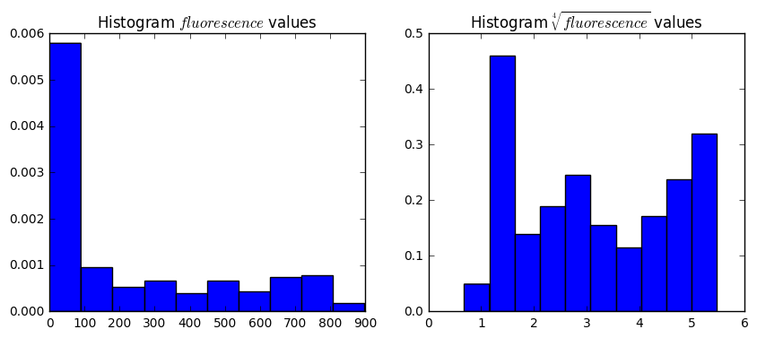

```python
yData = dfDataset['mean_score']
yRooted = [math.sqrt(math.sqrt(u)) for u in yData]
plt.figure(num=None, figsize=(10, 4), dpi=80, facecolor='w', edgecolor='k')
plt.subplot(121)
plt.hist(yData,10,normed=1)
plt.title('Histogram $fluorescence$ values')
plt.subplot(122)
plt.hist(yRooted,10,normed=1)
plt.title('Histogram $\sqrt[4]{fluorescence}$ values')
```

# K-fold Cross-Validation

# Nested K-fold Cross-Vallidation

# Code Implementation

The raw code for this IPython notebook is by default hidden for easier reading. To toggle on/off the raw code, click here.

**CODE SHOW** : turned ON

**CODE SHOW** : turned OFF

# Supported models

- **Ordinary Least Squares**: `OLS`

  ```
    Parameters: coef0
  ```

- **Ridge Regressen**: `ridge`

  ```
    Parameters: alpha, coef0
  ```

- **Lasso Regression**: `lasso`

  ```
    Parameters: alpha, coef0
  ```

- **Random Forests (Classification + Regression)** : `forestReg, forestClass`

  ```
    Parameters: max_depth, max_features, min_samples
  ```

- **Support vectors (Classification + Regression)** : `SVR`, `SVC`

  ```
    Parameters: alpha, gamma, coef0
    Kernels: poly, RBF, sigmoid, ...
  ```

- **Ridge regression kernels**: `ridge`

  ```
    Parameters: alpha, gamma, coef0
    Kernels: poly, RBF, sigmoid, ...
  ```

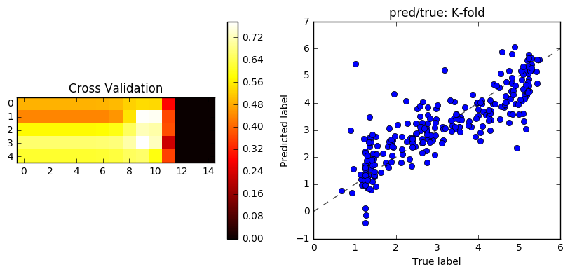

```python
# Model specification
parModel = {"regType":'ridge', "poly":3, "kernel":"poly", "coef0":1}
# To be evaluated parameter(s)
parLabel = ['alpha']
parRange = [15]
# Define kfold validation parameters
testSize = 0.2
k = 5
kInner = 5
#
X = positionBox.values
y = yRooted
# Run function
scoresParCV, optimalParCV = KfoldCV(X,y,k,parModel,parLabel[0],parRange[0])
```

```python
meanScores = np.mean(np.ndarray.max(scoresParCV,axis=1))
print("K FOLD CV \n---------- \n\n Maximum Score: ",np.max(scoresParCV), "\n Mean optimal score: ", meanScores ,"\n sd optimal scores: ", math.sqrt(np.sum(np.power((np.ndarray.max(scoresParCV,axis=1)-meanScores),2)))   , "\n Optimal parEval:\n", optimalParCV, "\n parEval Scores:\n", scoresParCV,"\n\n\n")\
```

```
K FOLD CV
----------

 Maximum Score:  0.777329178474
 Mean optimal score:  0.694151098598
 sd optimal scores:  0.1973422936419796
 Optimal parEval:
 [ 10.  10.  10.  10.  10.]
 parEval Scores:
 [[ 0.49073973  0.49073974  0.49073985  0.49074097  0.49075221  0.49086417
   0.49195034  0.50035653  0.5262695   0.53875493  0.53624175  0.28700519
  -1.34725368 -4.04082188 -4.8903711 ]
 [ 0.4378045   0.43780453  0.43780475  0.43780696  0.4378291   0.43804995
   0.44021082  0.45821118  0.54795707  0.77261323  0.76584795  0.36576166
  -1.18784964 -3.5496858  -4.27068806]
 [ 0.57585221  0.57585223  0.57585242  0.57585433  0.57587336  0.57606329
   0.57792223  0.59331349  0.6524615   0.72019771  0.70973664  0.3759356
  -1.20167623 -3.56089548 -4.27448499]
 [ 0.66405415  0.66405416  0.66405426  0.66405519  0.66406451  0.66415753
   0.66506463  0.67246767  0.70841709  0.77732918  0.72573051  0.22521816
  -1.9628223  -5.14708812 -6.07212235]
 [ 0.61576768  0.61576769  0.61576781  0.61576896  0.61578052  0.61589581
   0.61701887  0.62589272  0.65082317  0.66186044  0.59108463  0.36028076
  -0.95559811 -3.52121614 -4.34625736]]
```

```python
print("NESTED K FOLD CV \n----------------- \n\n Maximum Score: ",np.max(scoresParNCV), "\n Mean optimal score: ", np.mean(scoresParNCV) ,"\n sd optimal scores: ", math.sqrt(np.sum(np.power((np.ndarray.max(scoresParCV,axis=1)-np.mean(scoresParNCV)),2))) , "\n Optimal parEval:\n", optimalParNCV, "\n parEval Scores:\n", scoresParNCV,"\n\n\n")
```

```
NESTED K FOLD CV
-----------------

 Maximum Score:  0.777329178474
 Mean optimal score:  0.694151098598
 sd optimal scores:  0.1973422936419796
 Optimal parEval:
 [[ 10.  10.  10.  10.  10.]
 [ 10.  10.  10.  10.  10.]
 [ 10.  10.  10.  10.  10.]
 [ 10.  10.  10.  10.  10.]
 [ 10.  10.  10.  10.  10.]]
 parEval Scores:
 [ 0.53875493  0.77261323  0.72019771  0.77732918  0.66186044]
```

# Validation

The raw code for this IPython notebook is by default hidden for easier reading. To toggle on/off the raw code, click here.

**CODE SHOW** : turned ON

**CODE SHOW** : turned OFF

# Something about rank

**Spearman's rank correlation coefficient**

# Anderson promoter databank

- 19 well-recognized promoters
- recovered by Chris Anderson
- sequence range: $ [-35,1]$
- single nucleotide variations

```python
dfDatasetTest = pd.read_csv("data/anderson_lib.csv")
dfDatasetTest['sequence'] = dfDatasetTest['sequence'].str.upper()
dfDatasetTest.iloc[:10,:3]
```

|  | ID | sequence | mean_score |
| --- | --- | --- | --- |
| 0 | BBa_J23100 | TTGACGGCTAGCTCAGTCCTAGGTACAGTGCTAGC | 1.00 |
| 1 | BBa_J23101 | TTTACAGCTAGCTCAGTCCTAGGTATTATGCTAGC | 0.70 |
| 2 | BBa_J23102 | TTGACAGCTAGCTCAGTCCTAGGTACTGTGCTAGC | 0.86 |
| 3 | BBa_J23103 | CTGATAGCTAGCTCAGTCCTAGGGATTATGCTAGC | 0.01 |
| 4 | BBa_J23104 | TTGACAGCTAGCTCAGTCCTAGGTATTGTGCTAGC | 0.72 |
| 5 | BBa_J23105 | TTTACGGCTAGCTCAGTCCTAGGTACTATGCTAGC | 0.24 |
| 6 | BBa_J23106 | TTTACGGCTAGCTCAGTCCTAGGTATAGTGCTAGC | 0.47 |
| 7 | BBa_J23107 | TTTACGGCTAGCTCAGCCCTAGGTATTATGCTAGC | 0.36 |
| 8 | BBa_J23108 | CTGACAGCTAGCTCAGTCCTAGGTATAATGCTAGC | 0.51 |
| 9 | BBa_J23109 | TTTACAGCTAGCTCAGTCCTAGGGACTGTGCTAGC | 0.04 |

```
[['TTGACGGCTAGCTCAGTCCTAGGTACAGTGCTAGC' 1.0 1.1471200314792327]
 ['TTTACAGCTAGCTCAGTCCTAGGTATTATGCTAGC' 0.7 1.1784150086210976]
 ['TTGACAGCTAGCTCAGTCCTAGGTACTGTGCTAGC' 0.86 1.1422914010206398]
 ['CTGATAGCTAGCTCAGTCCTAGGGATTATGCTAGC' 0.01 1.024536186967578]
 ['TTGACAGCTAGCTCAGTCCTAGGTATTGTGCTAGC' 0.72 1.2110597706589332]
 ['TTTACGGCTAGCTCAGTCCTAGGTACTATGCTAGC' 0.24 1.0420465078330077]
 ['TTTACGGCTAGCTCAGTCCTAGGTATAGTGCTAGC' 0.47 1.1173812358558448]
 ['TTTACGGCTAGCTCAGCCCTAGGTATTATGCTAGC' 0.36 1.1344266302162562]
 ['CTGACAGCTAGCTCAGTCCTAGGTATAATGCTAGC' 0.51 1.2523398233146614]
 ['TTTACAGCTAGCTCAGTCCTAGGGACTGTGCTAGC' 0.04 0.9741051415861145]
 ['TTTACGGCTAGCTCAGTCCTAGGTACAATGCTAGC' 0.33 1.1156192146587767]
 ['TTGACGGCTAGCTCAGTCCTAGGTATAGTGCTAGC' 0.58 1.2178802066452625]
 ['CTGATAGCTAGCTCAGTCCTAGGGATTATGCTAGC' 0.0 1.024536186967578]
 ['CTGATGGCTAGCTCAGTCCTAGGGATTATGCTAGC' 0.01 0.9619583837616852]
 ['TTTATGGCTAGCTCAGTCCTAGGTACAATGCTAGC' 0.1 1.0451343320693378]
 ['TTTATAGCTAGCTCAGCCCTTGGTACAATGCTAGC' 0.15 1.1448173006737303]
 ['TTGACAGCTAGCTCAGTCCTAGGGACTATGCTAGC' 0.16 1.1300109196212154]
 ['TTGACAGCTAGCTCAGTCCTAGGGATTGTGCTAGC' 0.06 1.1317057327639775]
 ['TTGACGGCTAGCTCAGTCCTAGGTATTGTGCTAGC' 0.56 1.1399864680746752]]
SpearmanrResult(correlation=0.80728709394205445, pvalue=2.9393274121457126e-05)
```

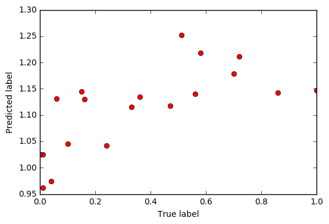

```python
labelsTest, positionBoxTest, spacerTest = regionSelect(dfDatasetTest, ROI, seqRange)
Xtest = positionBoxTest.values

parInput = {"regType":'ridge', "poly":3, "kernel":'poly', "gamma":0.1, "alpha": 10000, "coef0":1}
reg = selectRegression(**parInput)
reg.fit(X,y)
rankPredict = reg.predict(Xtest)

print(np.transpose(np.vstack((dfDatasetTest['sequence'].values,dfDatasetTest['mean_score'].values,rankPredict))))
print(stats.spearmanr(dfDatasetTest['mean_score'].values,rankPredict))
plt.plot(dfDatasetTest['mean_score'].values,rankPredict, 'ro')
plt.xlabel('True label')
plt.ylabel('Predicted label')
```

# Brewster promoter databank

- 18 promoters
- sequence range: $ [-40,-1]$
- single nucleotide variations focused in TATA and TTGACA box

```python
dfDatasetTest = pd.read_csv("data/brewster_lib.csv")
dfDatasetTest.iloc[:10,:3]
```

[output not shown]

```
[['TCGAGTTTACACTTTATGCTTCCGGCTCGTATAATGTGTGG' 41.8 1.4571109076964426]
 ['CAGGCTTTACACTTTATGCTTCCGGCTCGTATGTTGTGTGG' 53.45 1.315819923856125]
 ['CAGGCATTACACTTTATGCTTCCGGCTCGTATGTTGTGTGG' 57.83 1.2069529852360443]
 ['CAGGCTTAAGACTTTATGCTTCCGGCTCGTATGTTGTGTGG' 69.03 1.2225684259779572]
 ['CAGGCCTTAGACTTTATGCTTCCGGCTCGTATGTTGTGTGG' 69.93 1.1253936549415922]
 ['CAGGCCTCAGACTTTATGCTTCCGGCTCGTATGTTGTGTGG' 76.0 1.1262463076751201]
 ['CAGGCTTTACACTTTATGCTTCCGGCTCGGTTGTAGTGTGG' 81.46 1.0399968528358166]
 ['TCGCGTTTACACTTTATGCTTCCGGCTCGTATAATGTGTGG' 42.74 1.4433176505626932]
 ['TCGTGTTTACCCTTTATGCTTCCGGCTCGTATAATGTGTGG' 49.57 1.388553184749]
 ['TCGAGATTACACTTTATGCTTCCGGCTCGTATAATGTGTGG' 46.18 1.3400390969068956]
 ['TCGAGTTAAGACTTTATGCTTCCGGCTCGTATAATGTGTGG' 57.38 1.3595926486830499]
 ['TCGAGCTCAGACTTTATGCTTCCGGCTCGTATAATGTGTGG' 64.35 1.2559070198589966]
 ['TCGAGTTTACACTTTATGCTTCCGGCTCGTATAATGGGTGG' 42.7 1.4079548712827463]
 ['TCGAGTTTACACTTTATGCTTCCGGCTCGTATAATGGGAGG' 42.85 1.3103225002460042]
 ['TCGAGTTTACACTTTATGCTTCCGGCTCGAATAATGTGTGG' 46.74 1.3688025498043352]
 ['TCGAGTTTACACTTTATGCTTCCGGCTCGGATAATGTGTGG' 51.76 1.3610909858252953]
 ['TCGAGTTTACACTTTATGCTTCCGGCTCGGATAACGTGTGG' 62.58 1.2490720455876942]
 ['TCGAGTTTACACTTTATGCTTCCGGCTCGGTTAAAGTGTGG' 69.81 1.157577539204448]]
SpearmanrResult(correlation=-0.91124871001031982, pvalue=1.4607836787089575e-07)
```

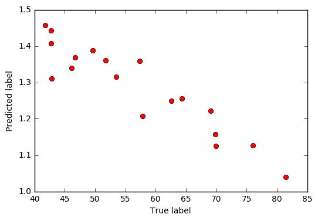

```python
labelsTest, positionBoxTest, spacerTest = regionSelect(dfDatasetTest, ROI, seqRange)
Xtest = positionBoxTest.values

rankPredict = reg.predict(Xtest)
print(np.transpose(np.vstack((dfDatasetTest['sequence'].values,dfDatasetTest['mean_score'].values,rankPredict))))
print(stats.spearmanr(dfDatasetTest['mean_score'].values,rankPredict))
plt.plot(dfDatasetTest['mean_score'].values,rankPredict, 'ro')
plt.xlabel('True label')
plt.ylabel('Predicted label')
```

# Hammer promoter databank

- 36 promoters
- sequence range: $ [-52,+7]$
- high level of variation over whole sequence

```python
dfDatasetTest = pd.read_csv("data/hammer_lib.csv")
dfDatasetTest.iloc[:10,:3]
```

|  | ID | sequence | mean_score |
| --- | --- | --- | --- |
| 0 | CP18=CP27 | CATTTTGCAGTTTATTCTTGACATTGTGTGCTTCGGGTGTATAATA... | 0.2 |
| 1 | CP37 | CATCATTAAGTTTATTCTTCACATTGGCCGGAATTGTTGTATAATA... | 16.0 |
| 2 | CP17 | CATTCTGGAGTTTATTCTTGACCGCTCAGTATGCAGTGGTATAATA... | 10.0 |
| 3 | CP2 | CATTTGCTAGTTTATTCTTGACATGAAGCGTGCCTAATGGTATATT... | 2.8 |
| 4 | CP4 | GATGTTTTAGTTTATTCTTGACACCGTATCGTGCGCGTGATATAAT... | 1.3 |
| 5 | CP44=CP45 | CATCGGGTAGTTTATTCTTGACAATTAAGTAGAGCCTGATATAATA... | 34.0 |
| 6 | CP1 | CATACCGGAGTTTATTCTTGACAGTTCCACCTCGGGTTGATATAAT... | 3.1 |
| 7 | CP19=CP22 | CATCGCTTAGTTTTTCTTGACAGGAGGGATCCGGGTTGATATAATA... | 3.3 |
| 8 | CP34 | CATCGCGAAGTTTATTCTTCACACACCGCAGAACTTGTGGTATAAT... | 8.4 |
| 9 | CP20 | CATGGGTGAGTTTATTCTTGACAGTGCGGCCGGGGGCTGATATCAT... | 22.0 |

```
SpearmanrResult(correlation=0.34255922865570765, pvalue=0.040839010065422274)
```

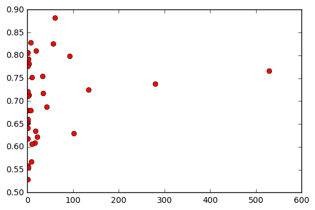

```python
labelsTest, positionBoxTest, spacerTest = regionSelect(dfDatasetTest, ROI, seqRange)
Xtest = positionBoxTest.values
rankPredict = reg.predict(Xtest)

print(stats.spearmanr(dfDatasetTest['mean_score'].values,rankPredict))
plt.plot(dfDatasetTest['mean_score'].values,rankPredict, 'ro')
```

# Inbio promoter databank

- 52 promoters
- sequence range: $ [-53,+4]$
- high level of variation over whole sequence

```python
dfDatasetTest = pd.read_csv("data/inbio_lib.csv")
dfDatasetTest.iloc[:10,:3].style.set_properties(**{"font-size":"10px"})
```

|  | ID | sequence | mean_score |
| --- | --- | --- | --- |
| 0 | p1 | TTAATCAATATTAGTTTCTTGACATCTTCTCCCGCATATGATATAATTAGTGAGTTACCATGGCGGCCGCTCTAGAAGAAGCTTGGGATCCGTCGACCTCGAATTCGGAGGAAACAAAGATG | 3779.86 |
| 1 | p11 | TTACTGGACAAAATTTTCTTGACATATTTTTCGTTATATGATATAATGATGAGGTTTCCATGGCGGCCGCTCTAGAAGAAGCTTGGGATCCGTCGACCTCGAATTCGGAGGAAACAAAGATG | 787.37 |
| 2 | p12 | TTAGAAGGAATTTGGTTCTTACATATTCGCACGCATGTGATATAATGGGGTTATTTCATGGCGGCCGCTSTAGAAGAAGCTTGGGATCCGTCGACCTSGAATTCGGAGGAAACAAAGATG | 154.69 |
| 3 | p13 | CATACAGTTAAATTCTTCTTGACATATTCGGGTAAATATGGTATAATGGGAGCATATCCATGGCGGCCGCTCTAGAAGAAGCTTGGGATCCGTCGACCTCGAATTCGGAGGAAACAAAGATG | 3149.04 |
| 4 | p14 | CTTCATTCTATAAGTTTCTTGACATCTTGGCCGGCATATGGTATAATAGGGAAATTTCCATGGCGGCCGCTCTAGAAGAAGCTTGGGATCCGTCGACCTCGAATTCGGAGGAAACAAAGATG | 7606.83 |
| 5 | p15 | GCTTGAGGTATAAAATTCTTGACATATTCCGTCGTTATGGTATAATGGTTCCATATCCATGGCGGCCGCTCTAGAAGAAGCTTGGGATCCGTCGACCTCGAATTCGGAGGAAACAAAGATG | 4783.13 |
| 6 | p16 | GCTTTTGGCAATTGGTTCTTGACATGTTGGCAGTTTGTGATATAATGGGGTCGTATCCATGGCGGCCGCTCTAGAAGAAGCTTGGGATCCGTCGACCTCGAATTCGGAGGAAACAAAGATG | 297.88 |
| 7 | p19 | CTAGTCTGGATTTACTTCTTGACATGTTGTCATCATTATGGTATAATGTTTAGGTATCCATGGCGGCCGCTCTAGAAGAAGCTTGGGATCCGTCGACCTCGAATTCGGAGGAAACAAAGATG | 4338.84 |
| 8 | p20 | ATTGAGTAGATAAGCTTCTTGACATCTTGGATGGATATGATATAATGTATGTGTATCCATGGCGGCCGCTCTAGAAGAAGCTTGGGATCCGTCGACCTCGAATTCGGAGGAAACAAAGATG | 854.61 |
| 9 | p22 | GCTTCATTTATAAATTTCTTGACATTTTGGAATAGATGTGATATAATGTGTACATATCCATGGCGGCCGCTCTAGAAGAAGCTTGGGATCCGTCGACCTCGAATTCGGAGGAAACAAAGATG | 3129.22 |

```
SpearmanrResult(correlation=0.024503212316951642, pvalue=0.86310286460841112)
```

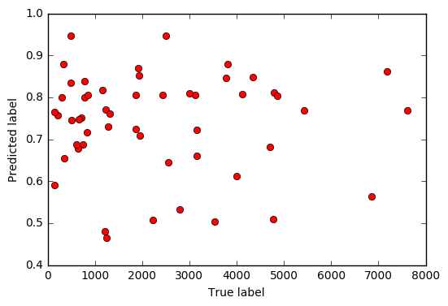

```python
labelsTest, positionBoxTest, spacerTest = regionSelect(dfDatasetTest, ROI, seqRange)
Xtest = positionBoxTest.values
rankPredict = reg.predict(Xtest)

print(stats.spearmanr(dfDatasetTest['mean_score'].values,rankPredict))
plt.plot(dfDatasetTest['mean_score'].values,rankPredict, 'ro')
plt.xlabel('True label')
plt.ylabel('Predicted label')
```

# Remarks

- Model is only strong in predicting changes within and in close range of the -35 and -10 regions
- Training data only encompasses the $[-47,1]$ region
- Simple features are used, giving a simple yet robust model
- Model has been optimized (used loss function) to minimize difference between predicted and true label

# Future work and focus

## Ranked based methods

[figure not shown]

## Neural Networks

- deepBind
- deepSea

[figure not shown]